# R Notebook

```r
source("main.R")
```

**FUNKCIJA**: *`linear_curve_2_points`*

- **…** : lista točaka oblika p = (x1, y1, x2, y2)
- **title**: naslov prikazanog grafa
- **colors**: boje krivulja
- **minX**: minimalna vrijednost koordinatne osi x, **DEFAULT**=0
- **maxX**: maksimalna vrijednost koordinatne osi x, **DEFAULT**=10
- **minY**: minimalna vrijednost koordinatne osi y, **DEFAULT**=0
- **maxY**: maksimalna vrijednost koordinatne osi y, **DEFAULT**=10
- **xlabel**: oznaka x osi, **DEFAULT**=“Q - quantity”
- **ylabel**: oznaka y osi, **DEFAULT**=“P - price”
- **pointsHidden**: jesu li točke sakrivene, **DEFAULT**=TRUE
- **lineCoordinateHidden**: jesu li točke označene na koordinatama, **DEFAULT**=TRUE
- **gg**: graf na kojem će biti nacrtane krivulje, **DEFAULT**=NULL

Prikaz ponude

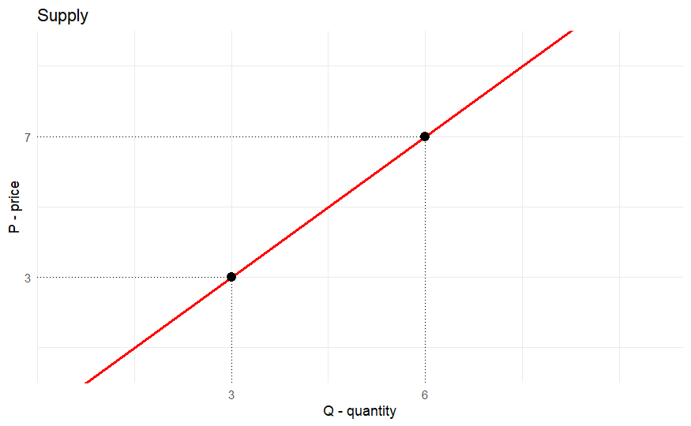

```r
p1 <- c(3, 3, 6, 7)

linear_curve_supply <- linear_curve_2_points(p1, title = "Supply", colors = "red", pointsHidden = FALSE, lineCoordinateHidden = FALSE)

supply_curve <- linear_curve_supply$curves
supply_plot <- linear_curve_supply$plot

supply_plot
```

Prikaz potražnje

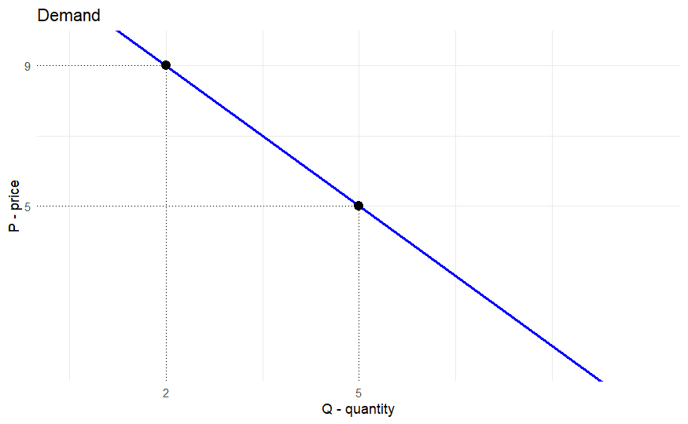

```r
p2 <- c(2, 9, 5, 5)
linear_curve_demand <- linear_curve_2_points(p2, title = "Demand", colors = "blue", pointsHidden = FALSE, lineCoordinateHidden = FALSE)

demand_curve <- linear_curve_demand$curves
demand_plot <- linear_curve_demand$plot

demand_plot
```

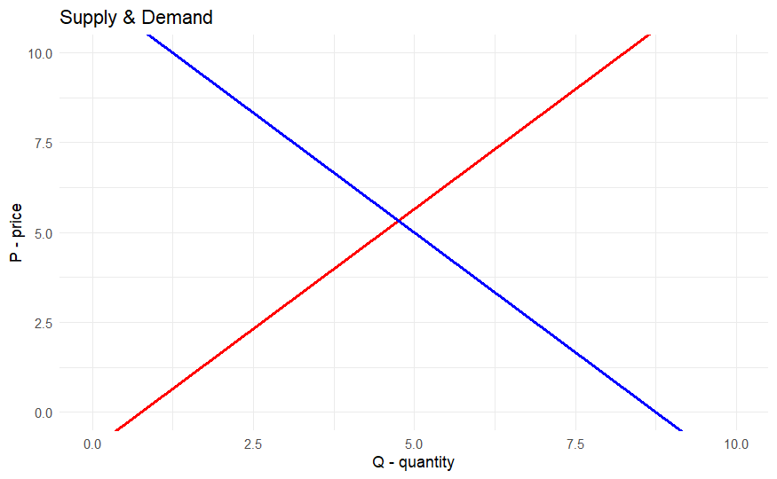

```r
linear_curve_supply_demand <- linear_curve_2_points(p1, p2, title = "Supply & Demand", colors = c("red", "blue"))

supply_demand_curves <- linear_curve_supply_demand$curves

supply_demand_plot <- linear_curve_supply_demand$plot
supply_demand_plot
```

**FUNKCIJA**: *`linear_curve_characteristic`*

- **…** : lista točaka oblika c = (nagib, odsječak)
- **title**: naslov prikazanog grafa
- **colors**: boje krivulja
- **minX**: minimalna vrijednost koordinatne osi x, **DEFAULT**=0
- **maxX**: maksimalna vrijednost koordinatne osi x, **DEFAULT**=10
- **minY**: minimalna vrijednost koordinatne osi y, **DEFAULT**=0
- **maxY**: maksimalna vrijednost koordinatne osi y, **DEFAULT**=10
- **xlabel**: oznaka x osi, **DEFAULT**=“Q - quantity”
- **ylabel**: oznaka y osi, **DEFAULT**=“P - price”ž
- **gg**: graf na kojem će biti nacrtane krivulje, **DEFAULT**=NULL

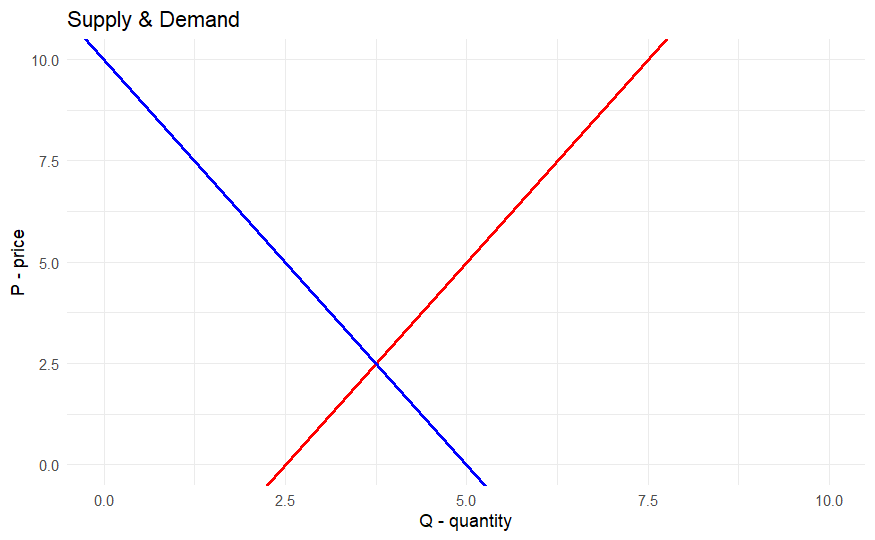

```r
linear_curve_characteristic_supply_demand <- linear_curve_characteristic(c(2, -5), c(-2, 10), title = "Supply & Demand", colors = c("red", "blue"))

supply_demand_curves <- linear_curve_characteristic_supply_demand$curves
supply_demand_plot_2 <- linear_curve_characteristic_supply_demand$plot

supply_demand_plot_2
```

**FUNKCIJA**: *`curve_N_points`*

- **…** : lista krivulja, npr. bezier(x = c(x1, x2, x3), y = c(y1, y2, y3)) %>% as.data.frame()
- **title**: naslov prikazanog grafa
- **colors**: boje krivulja
- **minX**: minimalna vrijednost koordinatne osi x, **DEFAULT**=0
- **maxX**: maksimalna vrijednost koordinatne osi x, **DEFAULT**=10
- **minY**: minimalna vrijednost koordinatne osi y, **DEFAULT**=0
- **maxY**: maksimalna vrijednost koordinatne osi y, **DEFAULT**=10
- **xlabel**: oznaka x osi, **DEFAULT**=“Q - quantity”
- **ylabel**: oznaka y osi, **DEFAULT**=“P - price”
- **gg**: graf na kojem će biti nacrtane krivulje, **DEFAULT**=NULL

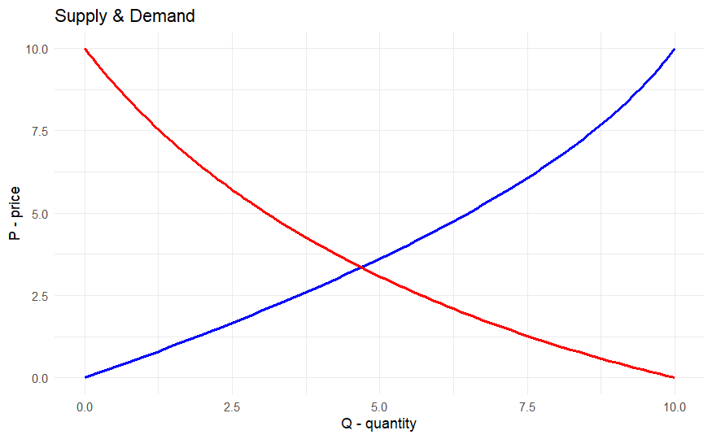

```r
supply <- bezier(x = c(0, 8, 10), y = c(0, 5, 10)) %>% as.data.frame()
demand <- bezier(x = c(0, 3, 10), y = c(10, 3, 0)) %>% as.data.frame()

curve_N_points(supply, demand, title = "Supply & Demand", colors = c("blue", "red"))
```

**FUNKCIJA**: *`curve_by_function`*

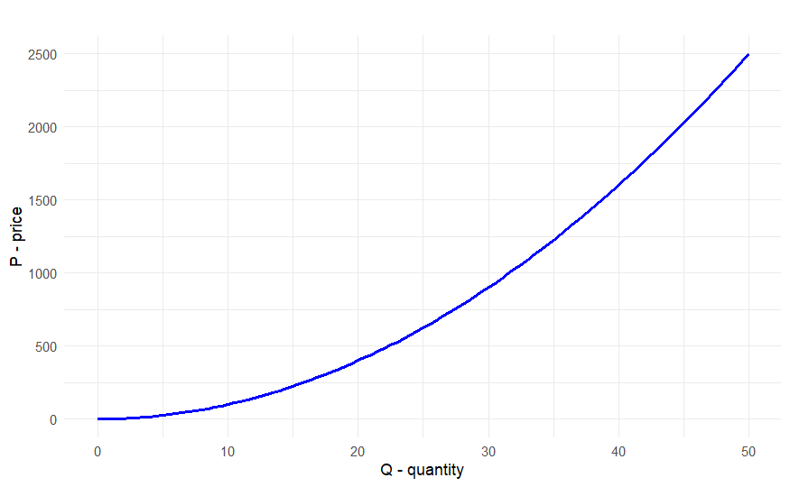

```r
my_function1 <- function(x) {
    return(x^2)
}

curve_by_function(my_function1)
```

Naslov, boja, nazivi na osima.

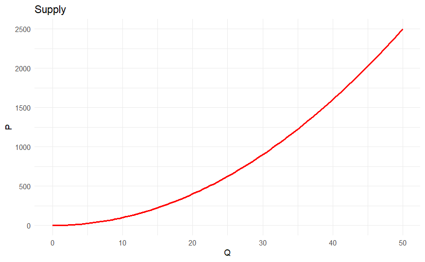

```r
curve_by_function(my_function1, title = "Supply", color = "red", xlabel = "Q", ylabel = "P")
```

Prikaz određenih brojki na osima

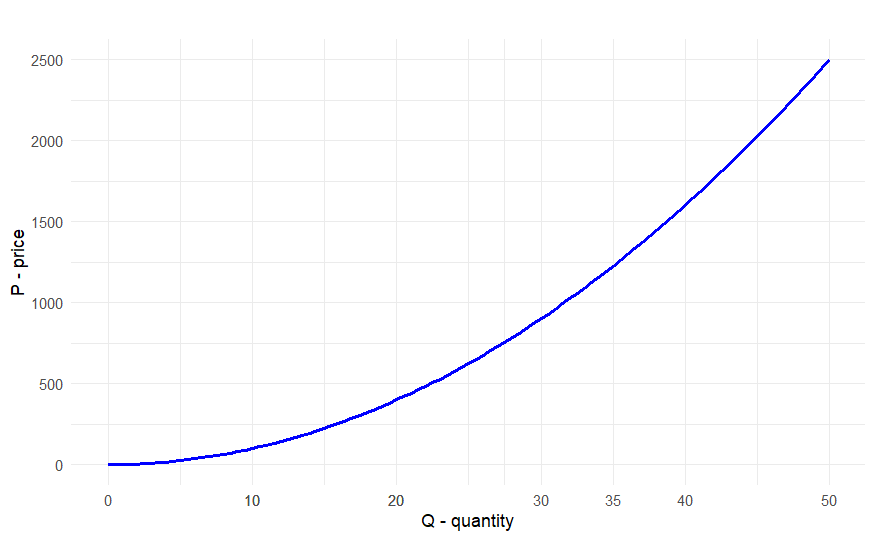

```r
axis_values <- c(10, 20, 35)

curve_by_function(my_function1, axisValues = axis_values)
```

Dodavanje natpisa uz krivulje

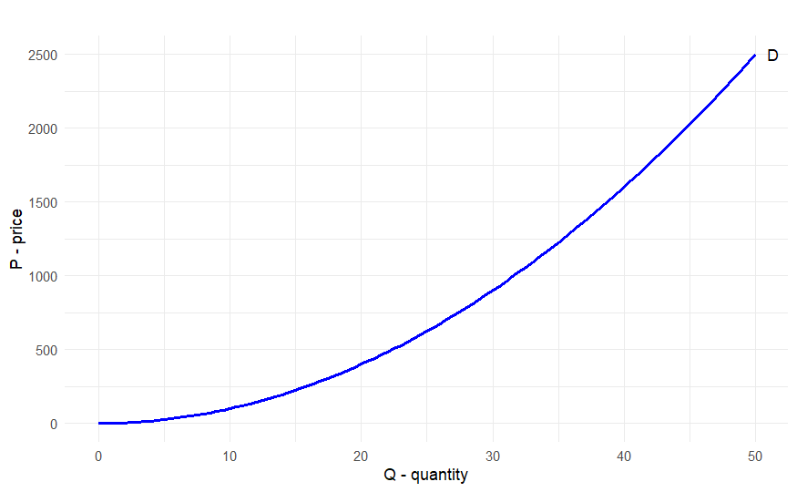

```r
curve_by_function(my_function1, label = "D")
```

Dodavanje točaka:  
- dodavanje linija prema osima iz tih točaka  
- označavanje na osima vrijednosti koje tim točkama pripadaju  
- dodavanje imena točkama

1. Dodavanje točaka uz specifikaciju koordinata

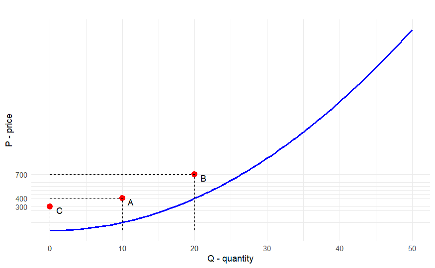

```r
point_x <- c(10, 20, 0)
point_y <- c(400, 700, 300)
labels <- c("A", "B", "C")

curve_by_function(my_function1, x_coordinates = point_x, y_coordinates = point_y, pointColor = "red", pointLabel = labels)
```

2. Dodavanje točaka kao sjecište zadane krivulje i pravca x=“zadana vrijednost”

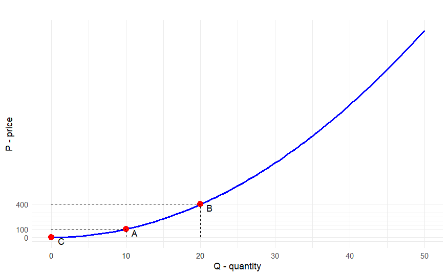

```r
point_x <- c(10, 20, 0)
labels <- c("A", "B", "C")

curve_by_function(my_function1, x_coordinates = point_x, pointColor = "red", pointLabel = labels)
```

Dodavanje točaka bez linija prema osima, bez pripadnih vrijednosti na osima i bez imena točaka.

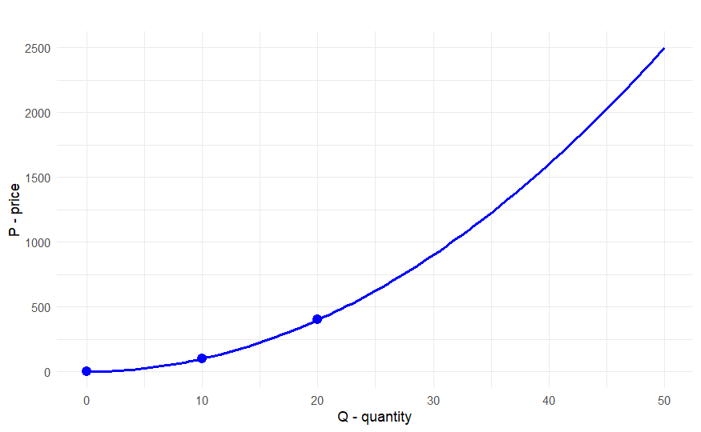

```r
my_function1 <- function(x) {
    return(x^2)
}
point_x <- c(10, 20, 0)
labels <- c("A", "B", "C")

curve_by_function(my_function1, x_coordinates = point_x, pointLabel = labels, showInfo = FALSE)
```

Više funkcija

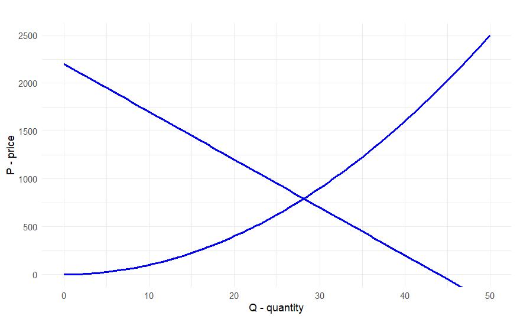

```r
my_function2 <- function(x) {
    return(-50 * x + 2200)
}

curve_by_function(my_function1, my_function2)
```

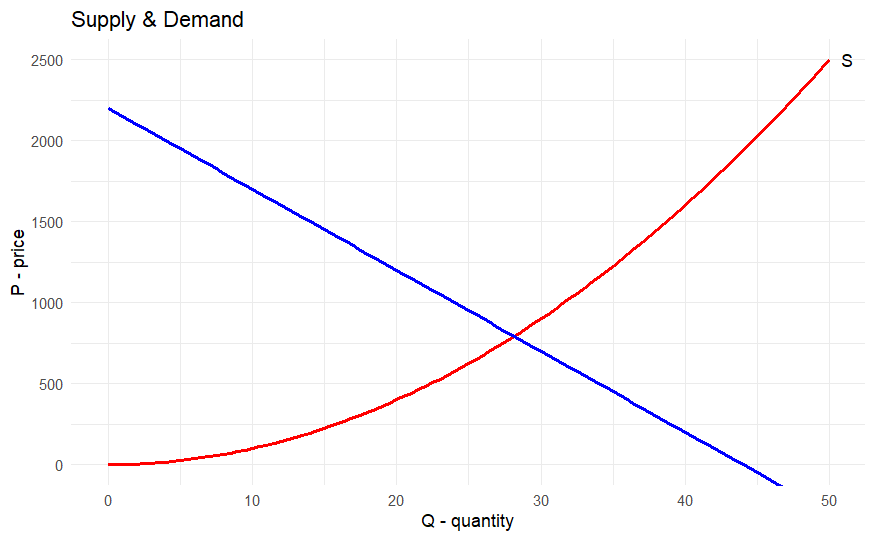

```r
curveLabels <- c("S", "D")

curve_by_function(my_function1, my_function2, title = "Supply & Demand", color = c("red", "blue"), label = curveLabels)
```

Dodavanje točaka.

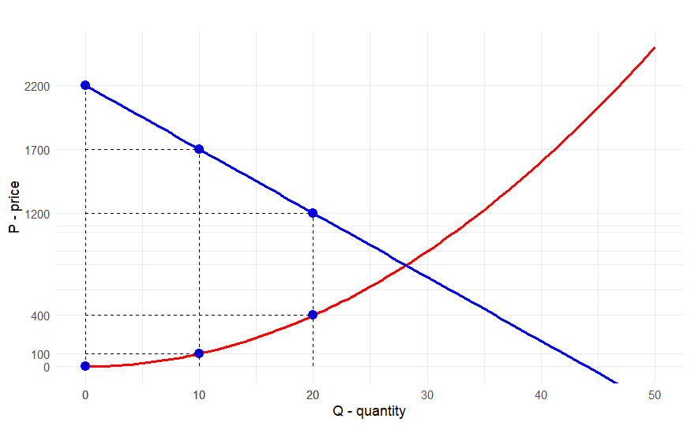

```r
point_x <- c(10, 20, 0)


curve_by_function(my_function1, my_function2, color = c("red", "blue"), x_coordinates = point_x)
```

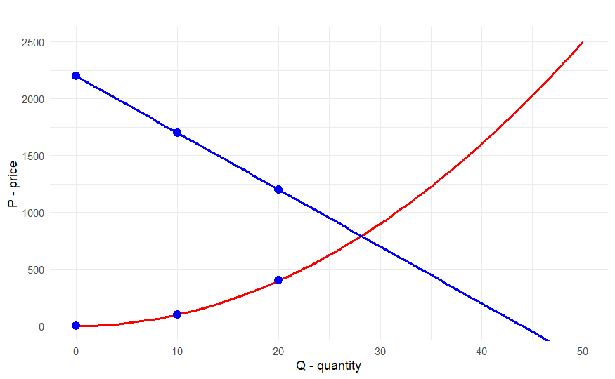

```r
point_x <- c(10, 20, 0)
labels <- c("A", "a", "B", "b", "C", "c")

curve_by_function(my_function1, my_function2, color = c("red", "blue"), x_coordinates = point_x, pointLabel = labels, showInfo = FALSE)
```

Više od dvije funkcije

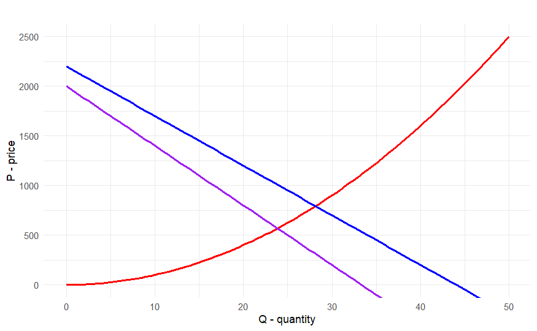

```r
my_function3 <- function(x) {
    return(-60 * x + 2000)
}

curve_by_function(my_function1, my_function2, my_function3, color = c("red", "blue", "purple"))
```

**FUNKCIJA**: *`move_curves_along_x_axis`*

- **…** : lista krivulja
- **offset** : pomak, **DEFAULT**=0
- **is_percentage** : je li pomak zadan u postotku, **DEFAULT**=FALSE
- **title**: naslov prikazanog grafa, **DEFAULT**=“Move along x-axis”
- **color**: boje orginalnih krivulja, **DEFAULT**=“blue”
- **color2**: boje pomaknutih krivulja, **DEFAULT**=“red”
- **minX**: minimalna vrijednost koordinatne osi x, **DEFAULT**=0
- **maxX**: maksimalna vrijednost koordinatne osi x, **DEFAULT**=20
- **xlabel**: oznaka x osi, **DEFAULT**=“x”
- **ylabel**: oznaka y osi, **DEFAULT**=“y”

Pomicanje grafa po x osi

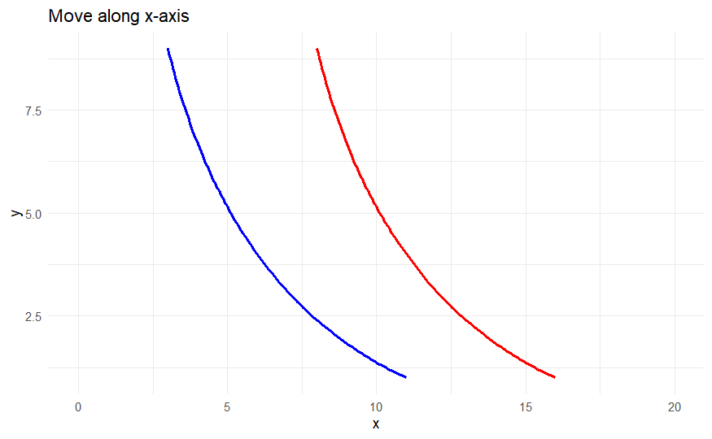

```r
curve_data <- bezier(x = c(3, 5, 11), y = c(9, 3, 1)) %>% as.data.frame()
move_curves_along_x_axis(curve_data, offset = 5)$plot
```

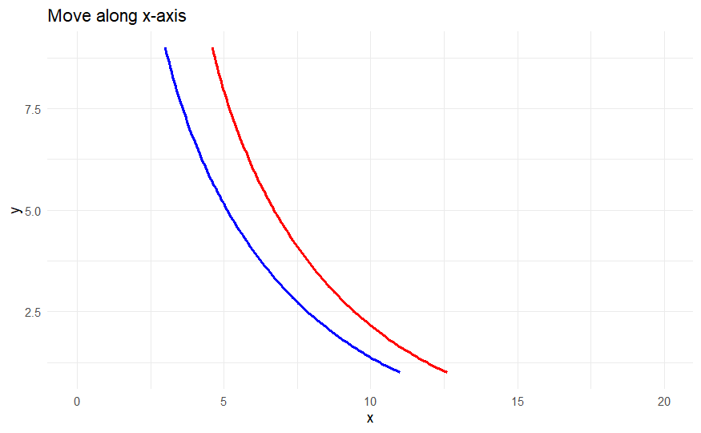

```r
move_curves_along_x_axis(curve_data, offset = 20, is_percentage = TRUE)$plot
```

**FUNKCIJA**: *`indifference_curve`*

- **x**: točke na x osi na temelju kojih se crta krivulja
- **y**: točke na y osi na temelju kojih se crta krivulja
- **n_curves**: broj krivulja, **DEFAULT**=“1”
- **x_intersections**: X vrijednosti gdje se nalaze sjecišta
- **labels**: oznake sjecišta
- **linecolor**: boje krivulja, **DEFAULT**=“black”
- **title**: naslov prikazanog grafa, **DEFAULT**=“Indifference curve”
- **xlabel**: oznaka x osi, **DEFAULT**=“X”
- **ylabel**: oznaka y osi, **DEFAULT**=“Y”

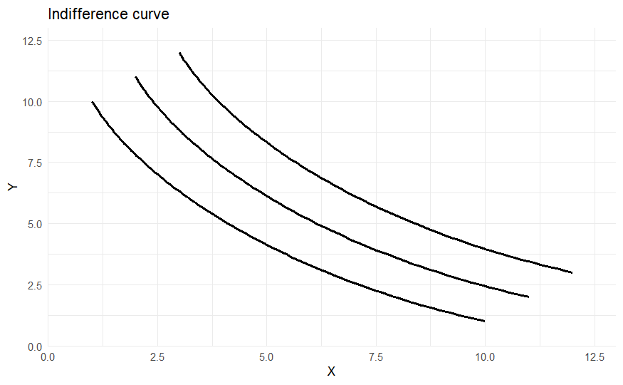

```r
indif <- indifference_curve(x = c(1, 2, 5, 10), y = c(10, 7, 3, 1), n_curves = 3)

indif$plot
```

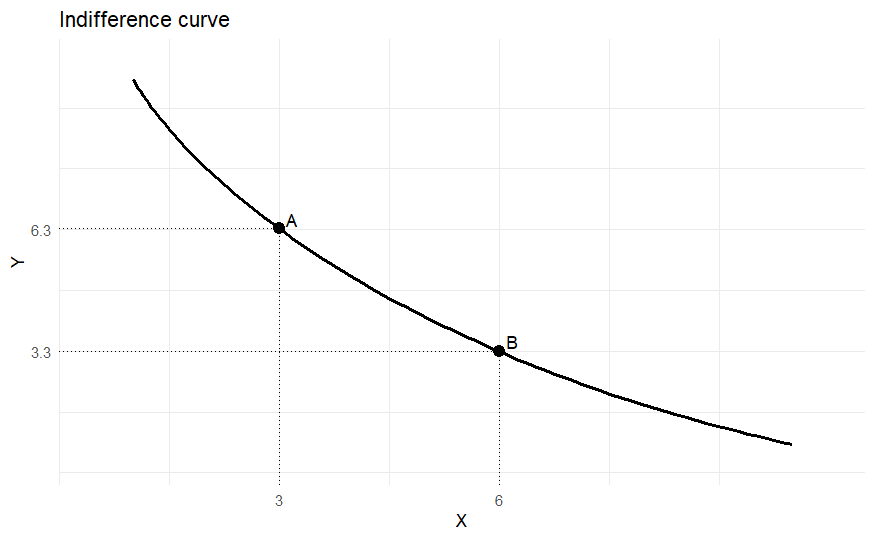

```r
indif <- indifference_curve(x = c(1, 2, 5, 10), y = c(10, 7, 3, 1), x_intersections = c(3, 6))

indif$plot
```

**FUNKCIJA**: *`isoquant`*

- **L**: lista vrijednosti rada
- **K**: lista vrijednosti kapitala
- **output_levels**: lista razina proizvodnje
- **A**: parametar proizvodnje
- **alpha**: elastičnost proizvodnje rada
- **beta**: elastičnost proizvodnje kapitala
- **color**: boje krivulja, **DEFAULT**=“black”

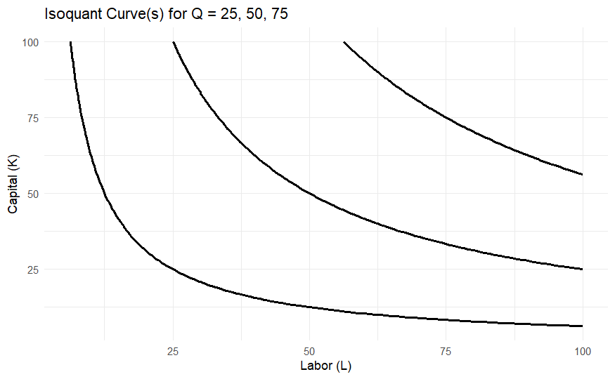

```r
L <- seq(1, 100, length.out = 100)
K <- seq(1, 100, length.out = 100)
output_levels <- c(25, 50, 75)

A <- 1
alpha <- 0.5
beta <- 0.5

isoquant(L, K, output_levels, A, alpha, beta)
```

**FUNKCIJA**: *`equilibrium`*

- **curve1** : prva krivulja
- **curve1**: druga krivulja
- **gg**: graf na kojem će se iscrtati točka presjeka prve i druge krivulje

```r
gg <- curve_N_points(supply, demand, title = "Supply & Demand", colors = c("blue", "red"))

PoE <- equilibrium(supply, demand, gg)
gg <- PoE$plot

PoE$x
```

```
[1] 4.686154
```

```r
PoE$y
```

```
[1] 3.349654
```

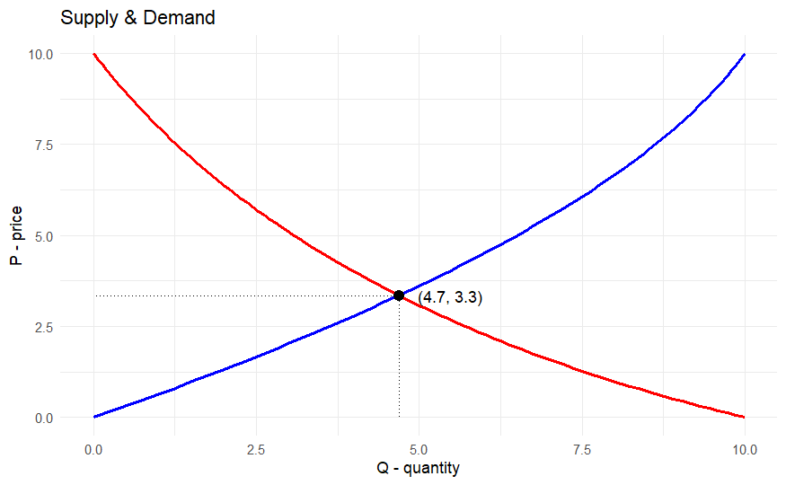

```r
gg
```

**FUNKCIJA**: *`supplier_revenue`*

- **curve1**: prva krivulja
- **curve2**: druga krivulja
- **gg**: plot na kojem se nalaze krivulje
- **color**: boja točke presjeka krivulja, **DEFAULT**=“green”
- **displayValue**: prikaz vrijednosti točke presjeka, **DEFAULT**=TRUE

```r
supply_sr <- bezier(x = c(0, 8, 10), y = c(0, 5, 10)) %>% as.data.frame()
demand_sr <- bezier(x = c(0, 3, 10), y = c(10, 3, 0)) %>% as.data.frame()

gg_sr <- curve_N_points(supply_sr, demand_sr, title = "Supply & Demand", colors = c("blue", "red"))

rev <- supplier_revenue(supply_sr, demand_sr, gg_sr, color = "purple")

gg_sr <- rev$plot

rev$revenue
```

```
[1] 15.697
```

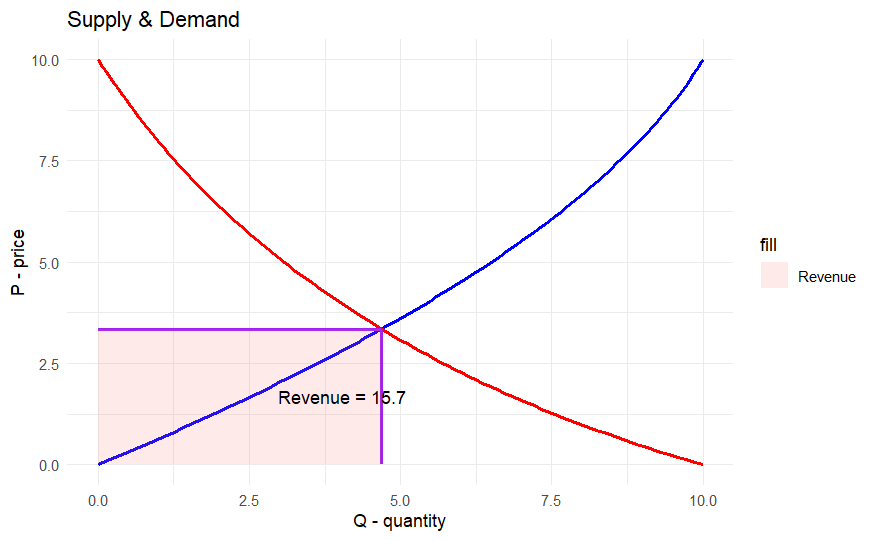

```r
gg_sr
```

**FUNKCIJA**: *`surplus_area`*

- **curve1**: prva krivulja
- **curve2**: druga krivulja
- **gg**: plot na kojem se nalaze krivulje

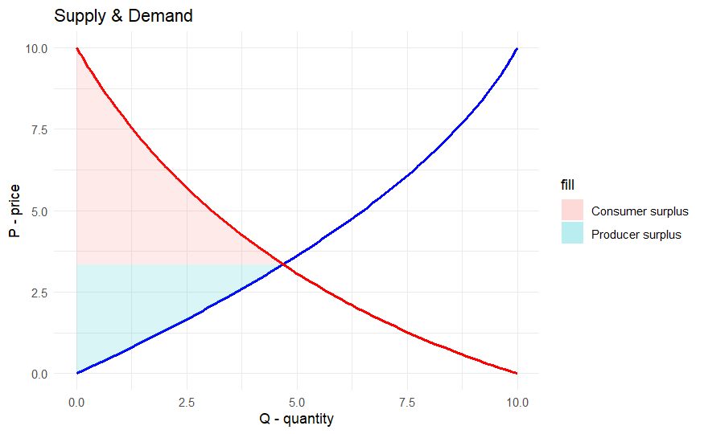

```r
supply_srp <- bezier(x = c(0, 8, 10), y = c(0, 5, 10)) %>% as.data.frame()
demand_srp <- bezier(x = c(0, 3, 10), y = c(10, 3, 0)) %>% as.data.frame()

gg_srp <- curve_N_points(supply_srp, demand_srp, title = "Supply & Demand", colors = c("blue", "red"))

surplus <- surplus_area(supply_srp, demand_srp, gg_srp)

surplus
```

**FUNKCIJA**: *`production_possibility_frontier`*

- **…** : granice proizvodnih mogućnosti
- **title**: naslov grafa, **DEFAULT**=“Production-possibility frontier”
- **colors**: boje krivulja
- **x**: točke na krivulji
- **lables**: oznake točaka na krivulji
- **xlabel**: oznaka x osi, **DEFAULT**=“Product A”
- **ylabel**: oznaka y osi, **DEFAULT**=“Product B”

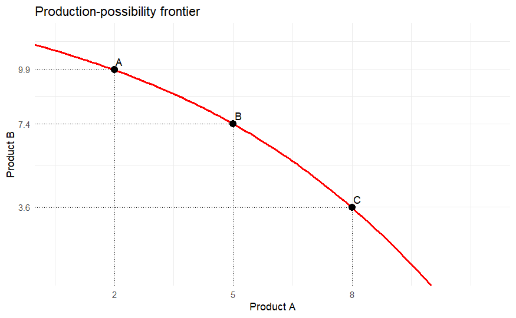

```r
curve_data <- bezier(x = c(0, 4, 7, 10), y = c(11, 9, 6, 0)) %>% as.data.frame()
production_possibility_frontier(curve_data, colors = "red", x = c(2, 5, 8), labels = c("A", "B", "C"))
```

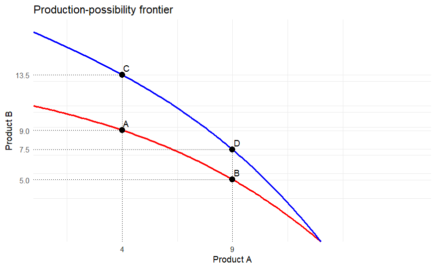

```r
curve_data1 <- bezier(x = c(0, 5, 9, 13), y = c(11, 9, 6, 0)) %>% as.data.frame()
curve_data2 <- bezier(x = c(0, 5, 9, 13), y = c(17, 13, 9, 0)) %>% as.data.frame()
production_possibility_frontier(curve_data1, curve_data2, colors = c("red", "blue"), x = c(4, 9), labels = c("A", "B", "C", "D"))
```

# DEMO

- prikaz kombiniranja funkcija

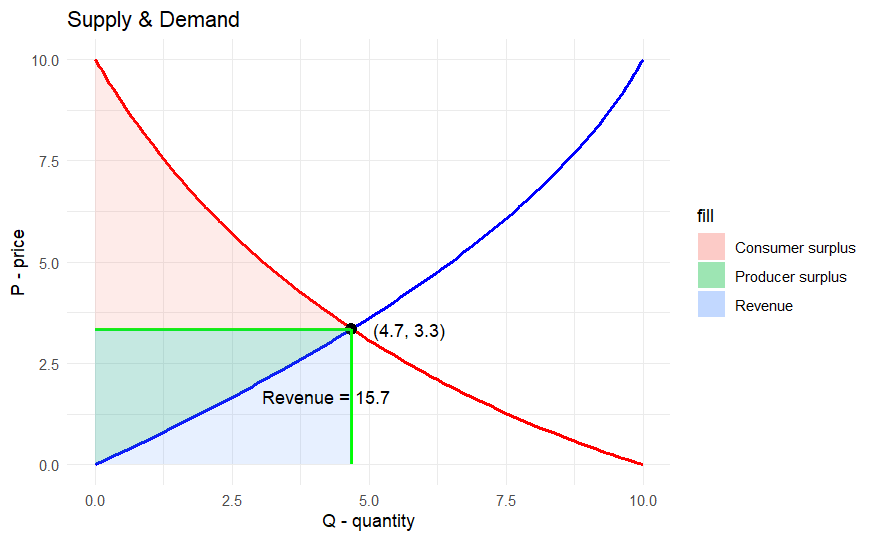

```r
supply <- bezier(x = c(0, 8, 10), y = c(0, 5, 10)) %>% as.data.frame()
demand <- bezier(x = c(0, 3, 10), y = c(10, 3, 0)) %>% as.data.frame()

supply_demand_plot <- curve_N_points(supply, demand, title = "Supply & Demand", colors = c("blue", "red"))

equi <- equilibrium(supply, demand, supply_demand_plot)

supply_demand_plot_with_equi <- equi$plot

sr <- supplier_revenue(supply, demand, supply_demand_plot_with_equi)

supply_demand_plot_with_equi_and_sr <- sr$plot

supply_demand_plot_with_equi_and_sr_and_surplus <- surplus_area(supply, demand, supply_demand_plot_with_equi_and_sr)

supply_demand_plot_with_equi_and_sr_and_surplus
```